# Predicting Stroke

##### 4.2.1.0.1 Linear Regression (OLS)

It is clear that *BMI is insignificant* in all 3 models that estimates probability of $Stroke$ (eq.(1),(2),(3)). However, we discovered that BMI has indications to be indirectly affecting stroke incidence. Following the AIC subset selection and the Lasso regularization, we individually regressed $AVGGlucose$, $Hypertension$ and $HeartDisease$ againts $BMI$ and found $BMI$ to have positive relationship with $AVGGlucose$ and $Hypertension$ but not with $HeartDisease$

```r
# We can really see that BMI does not significantly affect incidence of stroke in
# all possible models (AIC,BIC), but lets see if BMI affects hypertension, glucose level, heart disease
modelGlucoseBMI = lm(avg_glucose_level~ bmi, data = trainData)
summary(modelGlucoseBMI)  #IT DOES!!!!
```

```
##
## Call:
## lm(formula = avg_glucose_level ~ bmi, data = trainData)
##
## Residuals:
##     Min      1Q  Median      3Q     Max
## -114.75  -31.78  -14.64   10.78  162.57
##
## Coefficients:
##             Estimate Std. Error t value Pr(>|t|)
## (Intercept)  78.0922     3.9974  19.536  < 2e-16 ***
## bmi           1.0169     0.1283   7.926 3.34e-15 ***
## ---
## Signif. codes:  0 '***' 0.001 '**' 0.01 '*' 0.05 '.' 0.1 ' ' 1
##
## Residual standard error: 47.61 on 2567 degrees of freedom
## Multiple R-squared:  0.02389,    Adjusted R-squared:  0.02351
## F-statistic: 62.82 on 1 and 2567 DF,  p-value: 3.343e-15
```

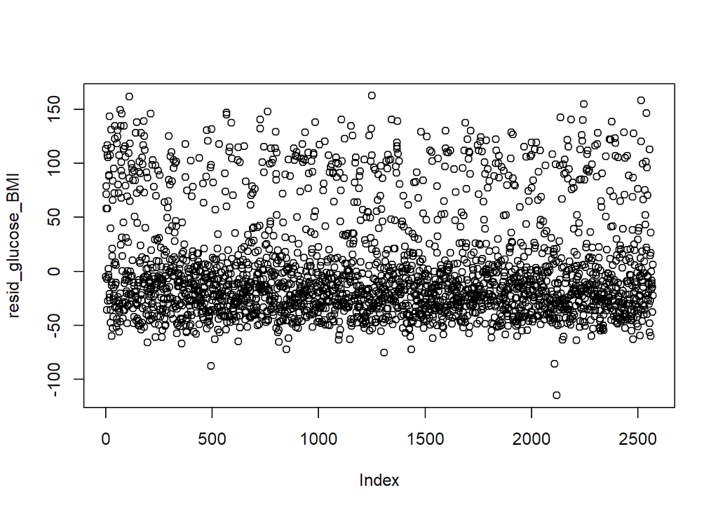

```r
resid_glucose_BMI <- residuals(modelGlucoseBMI)
plot(resid_glucose_BMI) #residuals seem to have neither patterns nor variations, Homoskedastic.
```

```r
modelHypertensionBMI = glm(hypertension ~ bmi, trainData, family="binomial")
summary(modelHypertensionBMI)  #YES IT DOES
```

```
##
## Call:
## glm(formula = hypertension ~ bmi, family = "binomial", data = trainData)
##
## Deviance Residuals:
##     Min       1Q   Median       3Q      Max
## -1.2736  -0.5300  -0.4682  -0.4150   2.4067
##
## Coefficients:
##              Estimate Std. Error z value Pr(>|z|)
## (Intercept) -3.646648   0.245954 -14.827  < 2e-16 ***
## bmi          0.053826   0.007348   7.325 2.39e-13 ***
## ---
## Signif. codes:  0 '***' 0.001 '**' 0.01 '*' 0.05 '.' 0.1 ' ' 1
##
## (Dispersion parameter for binomial family taken to be 1)
##
##     Null deviance: 1923.6  on 2568  degrees of freedom
## Residual deviance: 1871.5  on 2567  degrees of freedom
## AIC: 1875.5
##
## Number of Fisher Scoring iterations: 4
```

```r
modelHeartdiseaseBMI = glm(heart_disease ~ bmi, trainData, family="binomial")
summary(modelHeartdiseaseBMI)  #Nope
```

```
##
## Call:
## glm(formula = heart_disease ~ bmi, family = "binomial", data = trainData)
##
## Deviance Residuals:
##     Min       1Q   Median       3Q      Max
## -0.4139  -0.3635  -0.3594  -0.3560   2.3718
##
## Coefficients:
##              Estimate Std. Error z value Pr(>|z|)
## (Intercept) -2.838911   0.341397  -8.316   <2e-16 ***
## bmi          0.004618   0.010871   0.425    0.671
## ---
## Signif. codes:  0 '***' 0.001 '**' 0.01 '*' 0.05 '.' 0.1 ' ' 1
##
## (Dispersion parameter for binomial family taken to be 1)
##
##     Null deviance: 1209.0  on 2568  degrees of freedom
## Residual deviance: 1208.8  on 2567  degrees of freedom
## AIC: 1212.8
##
## Number of Fisher Scoring iterations: 5
```

Age was excluded because of the assumption that BMI should be self-regulated despite of any age a person is (BMI is merely a basic measure of body composition and not a medical occurence that changes due to aging process). BMI, however, is directly proportionate to the chances of having hypertension and high average glucose level in the blood stream which affects the probability of stroke occuring. On the other hand, there is no statistical evidence that a person’s BMI affects his/her chances of getting a heart disease. In other words, there exist *indirect relationship between BMI and stroke incidence*, via $AVGGlucose$, $Hypertension$.

### 4.2.2 What Other Variables Indirectly Affect Stroke Incidence?

For each of the explanatory variables that have significance in predicting $Stroke$, we regress them as independent variables againts all possible variables available in our dataset (other than stroke itself) and pick up the significant regressors using another stepwise selection method with BIC as its penalty this time. Results are reported as the following:

$BMI$ and $Age$ has a positive relationship with the chances of having hypertension as well as $AvgGlucose$. $Hypertension$ and $AvgGlucose$ are inter-related (they affect each other) and there exist a cross relationship between $AvgGlucose$ and $HeartDisease$. There is also statistical evidence that men have higher chances of getting heart disease.

```
## Start:  AIC=1645.31
## hypertension ~ (gender + age + heart_disease + ever_married +
##     work_type + Residence_type + avg_glucose_level + bmi + smoking_status +
##     stroke) - stroke
##
##                     Df Deviance    AIC
## - work_type          4   1618.4 1638.4
## - ever_married       1   1617.3 1643.3
## - Residence_type     1   1617.5 1643.5
## - heart_disease      1   1617.8 1643.8
## - smoking_status     2   1620.9 1644.9
## <none>                   1617.3 1645.3
## - gender             1   1619.7 1645.7
## - avg_glucose_level  1   1633.1 1659.1
## - bmi                1   1669.0 1695.0
## - age                1   1748.6 1774.6
##
## Step:  AIC=1638.43
## hypertension ~ gender + age + heart_disease + ever_married +
##     Residence_type + avg_glucose_level + bmi + smoking_status
##
##                     Df Deviance    AIC
## - ever_married       1   1618.5 1636.5
## - Residence_type     1   1618.6 1636.6
## - heart_disease      1   1618.9 1636.9
## - smoking_status     2   1622.2 1638.2
## <none>                   1618.4 1638.4
## - gender             1   1620.7 1638.7
## + work_type          4   1617.3 1645.3
## - avg_glucose_level  1   1634.0 1652.0
## - bmi                1   1671.0 1689.0
## - age                1   1765.7 1783.7
##
## Step:  AIC=1636.48
## hypertension ~ gender + age + heart_disease + Residence_type +
##     avg_glucose_level + bmi + smoking_status
##
##                     Df Deviance    AIC
## - Residence_type     1   1618.7 1634.7
## - heart_disease      1   1618.9 1634.9
```

[output cut: 39 more lines]

```
##
## Step:  AIC=1632.97
## hypertension ~ gender + age + avg_glucose_level + bmi
##
##                     Df Deviance    AIC
## <none>                   1623.0 1633.0
## + smoking_status     2   1619.2 1633.2
## - gender             1   1625.6 1633.6
## + heart_disease      1   1622.4 1634.4
## + Residence_type     1   1622.8 1634.8
## + ever_married       1   1622.9 1634.9
## + work_type          4   1621.7 1639.7
## - avg_glucose_level  1   1639.2 1647.2
## - bmi                1   1674.9 1682.9
## - age                1   1803.6 1811.6
```

```
##
## Call:
## glm(formula = hypertension ~ gender + age + avg_glucose_level +
##     bmi, family = "binomial", data = trainData)
##
## Deviance Residuals:
##     Min       1Q   Median       3Q      Max
## -1.4537  -0.5507  -0.3414  -0.1851   2.9755
##
## Coefficients:
##                    Estimate Std. Error z value Pr(>|z|)
## (Intercept)       -7.573289   0.439307 -17.239  < 2e-16 ***
## genderMale         0.211764   0.129684   1.633    0.102
## age                0.053553   0.004435  12.075  < 2e-16 ***
## avg_glucose_level  0.004569   0.001121   4.077 4.55e-05 ***
## bmi                0.063433   0.008687   7.302 2.83e-13 ***
## ---
## Signif. codes:  0 '***' 0.001 '**' 0.01 '*' 0.05 '.' 0.1 ' ' 1
##
## (Dispersion parameter for binomial family taken to be 1)
##
##     Null deviance: 1923.6  on 2568  degrees of freedom
## Residual deviance: 1623.0  on 2564  degrees of freedom
## AIC: 1633
##
## Number of Fisher Scoring iterations: 6
```

```
## Start:  AIC=1727.22
## hypertension ~ (gender + age + heart_disease + ever_married +
##     work_type + Residence_type + avg_glucose_level + bmi + smoking_status +
##     stroke) - stroke
##
##                     Df Deviance    AIC
## - work_type          4   1618.4 1696.9
## - smoking_status     2   1620.9 1715.1
## - ever_married       1   1617.3 1719.4
## - Residence_type     1   1617.5 1719.6
## - heart_disease      1   1617.8 1719.9
## - gender             1   1619.7 1721.7
## <none>                   1617.3 1727.2
## - avg_glucose_level  1   1633.1 1735.2
## - bmi                1   1669.0 1771.0
## - age                1   1748.6 1850.7
##
## Step:  AIC=1696.94
## hypertension ~ gender + age + heart_disease + ever_married +
##     Residence_type + avg_glucose_level + bmi + smoking_status
##
##                     Df Deviance    AIC
## - smoking_status     2   1622.2 1685.0
## - ever_married       1   1618.5 1689.1
## - Residence_type     1   1618.6 1689.3
## - heart_disease      1   1618.9 1689.6
## - gender             1   1620.7 1691.4
## <none>                   1618.4 1696.9
## - avg_glucose_level  1   1634.0 1704.7
## + work_type          4   1617.3 1727.2
## - bmi                1   1671.0 1741.6
## - age                1   1765.7 1836.3
##
## Step:  AIC=1684.97
## hypertension ~ gender + age + heart_disease + ever_married +
##     Residence_type + avg_glucose_level + bmi
##
##                     Df Deviance    AIC
## - ever_married       1   1622.2 1677.2
## - Residence_type     1   1622.3 1677.3
```

[output cut: 55 more lines]

```
##
## Step:  AIC=1657.02
## hypertension ~ age + avg_glucose_level + bmi
##
##                     Df Deviance    AIC
## <none>                   1625.6 1657.0
## + gender             1   1623.0 1662.2
## + heart_disease      1   1624.8 1664.0
## + Residence_type     1   1625.4 1664.7
## + ever_married       1   1625.6 1664.8
## - avg_glucose_level  1   1643.0 1666.5
## + smoking_status     2   1621.7 1668.8
## + work_type          4   1624.4 1687.2
## - bmi                1   1676.8 1700.3
## - age                1   1806.8 1830.4
```

```
##
## Call:
## glm(formula = hypertension ~ age + avg_glucose_level + bmi, family = "binomial",
##     data = trainData)
##
## Deviance Residuals:
##     Min       1Q   Median       3Q      Max
## -1.3970  -0.5508  -0.3439  -0.1865   2.9468
##
## Coefficients:
##                    Estimate Std. Error z value Pr(>|z|)
## (Intercept)       -7.471497   0.431695 -17.307  < 2e-16 ***
## age                0.053515   0.004422  12.101  < 2e-16 ***
## avg_glucose_level  0.004710   0.001117   4.217 2.48e-05 ***
## bmi                0.062596   0.008605   7.275 3.47e-13 ***
## ---
## Signif. codes:  0 '***' 0.001 '**' 0.01 '*' 0.05 '.' 0.1 ' ' 1
##
## (Dispersion parameter for binomial family taken to be 1)
##
##     Null deviance: 1923.6  on 2568  degrees of freedom
## Residual deviance: 1625.6  on 2565  degrees of freedom
## AIC: 1633.6
##
## Number of Fisher Scoring iterations: 6
```

```
## Start:  AIC=972.27
## heart_disease ~ (gender + age + hypertension + ever_married +
##     work_type + Residence_type + avg_glucose_level + bmi + smoking_status +
##     stroke) - stroke
##
##                     Df Deviance     AIC
## - work_type          4   950.24  970.24
## - bmi                1   944.39  970.39
## - Residence_type     1   944.65  970.65
## - hypertension       1   945.12  971.12
## - ever_married       1   945.21  971.21
## <none>                   944.27  972.27
## - smoking_status     2   951.05  975.05
## - avg_glucose_level  1   955.00  981.00
## - gender             1   961.60  987.60
## - age                1  1101.71 1127.71
##
## Step:  AIC=970.24
## heart_disease ~ gender + age + hypertension + ever_married +
##     Residence_type + avg_glucose_level + bmi + smoking_status
##
##                     Df Deviance     AIC
## - bmi                1   950.41  968.41
## - Residence_type     1   950.54  968.54
## - hypertension       1   951.05  969.05
## - ever_married       1   951.07  969.07
## <none>                   950.24  970.24
## + work_type          4   944.27  972.27
## - smoking_status     2   956.94  972.94
## - avg_glucose_level  1   960.97  978.97
## - gender             1   967.96  985.96
## - age                1  1106.55 1124.55
##
## Step:  AIC=968.41
## heart_disease ~ gender + age + hypertension + ever_married +
##     Residence_type + avg_glucose_level + smoking_status
##
##                     Df Deviance     AIC
## - Residence_type     1   950.71  966.71
## - ever_married       1   951.23  967.23
```

[output cut: 40 more lines]

```
##
## Step:  AIC=964.49
## heart_disease ~ gender + age + avg_glucose_level + smoking_status
##
##                     Df Deviance     AIC
## <none>                   952.49  964.49
## + hypertension       1   951.52  965.52
## + ever_married       1   951.66  965.66
## + Residence_type     1   952.15  966.15
## + bmi                1   952.24  966.24
## + work_type          4   946.70  966.70
## - smoking_status     2   958.94  966.94
## - avg_glucose_level  1   965.35  975.35
## - gender             1   969.93  979.93
## - age                1  1129.85 1139.85
```

```
##
## Call:
## glm(formula = heart_disease ~ gender + age + avg_glucose_level +
##     smoking_status, family = "binomial", data = trainData)
##
## Deviance Residuals:
##     Min       1Q   Median       3Q      Max
## -1.3547  -0.3677  -0.1933  -0.0961   3.2126
##
## Coefficients:
##                             Estimate Std. Error z value Pr(>|z|)
## (Intercept)                -8.346363   0.536511 -15.557  < 2e-16 ***
## genderMale                  0.735555   0.177340   4.148 3.36e-05 ***
## age                         0.078033   0.006983  11.174  < 2e-16 ***
## avg_glucose_level           0.005183   0.001421   3.648 0.000264 ***
## smoking_statusnever smoked -0.154350   0.202827  -0.761 0.446660
## smoking_statussmokes        0.430019   0.238312   1.804 0.071163 .
## ---
## Signif. codes:  0 '***' 0.001 '**' 0.01 '*' 0.05 '.' 0.1 ' ' 1
##
## (Dispersion parameter for binomial family taken to be 1)
##
##     Null deviance: 1208.99  on 2568  degrees of freedom
## Residual deviance:  952.49  on 2563  degrees of freedom
## AIC: 964.49
##
## Number of Fisher Scoring iterations: 7
```

```
## Start:  AIC=1054.19
## heart_disease ~ (gender + age + hypertension + ever_married +
##     work_type + Residence_type + avg_glucose_level + bmi + smoking_status +
##     stroke) - stroke
##
##                     Df Deviance    AIC
## - work_type          4   950.24 1028.8
## - smoking_status     2   951.05 1045.3
## - bmi                1   944.39 1046.5
## - Residence_type     1   944.65 1046.7
## - hypertension       1   945.12 1047.2
## - ever_married       1   945.21 1047.3
## <none>                   944.27 1054.2
## - avg_glucose_level  1   955.00 1057.1
## - gender             1   961.60 1063.7
## - age                1  1101.71 1203.8
##
## Step:  AIC=1028.75
## heart_disease ~ gender + age + hypertension + ever_married +
##     Residence_type + avg_glucose_level + bmi + smoking_status
##
##                     Df Deviance    AIC
## - smoking_status     2   956.94 1019.8
## - bmi                1   950.41 1021.1
## - Residence_type     1   950.54 1021.2
## - hypertension       1   951.05 1021.7
## - ever_married       1   951.07 1021.7
## <none>                   950.24 1028.8
## - avg_glucose_level  1   960.97 1031.6
## - gender             1   967.96 1038.6
## + work_type          4   944.27 1054.2
## - age                1  1106.55 1177.2
##
## Step:  AIC=1019.76
## heart_disease ~ gender + age + hypertension + ever_married +
##     Residence_type + avg_glucose_level + bmi
##
##                     Df Deviance    AIC
## - bmi                1   957.07 1012.0
## - Residence_type     1   957.09 1012.0
```

[output cut: 55 more lines]

```
##
## Step:  AIC=990.34
## heart_disease ~ gender + age + avg_glucose_level
##
##                     Df Deviance     AIC
## <none>                   958.94  990.34
## - avg_glucose_level  1   971.13  994.68
## + hypertension       1   958.00  997.26
## + ever_married       1   958.12  997.37
## + bmi                1   958.76  998.01
## + Residence_type     1   958.76  998.02
## + smoking_status     2   952.49  999.60
## - gender             1   979.35 1002.90
## + work_type          4   953.22 1016.03
## - age                1  1137.82 1161.38
```